# Wpływ cech czerwonego wina na jego jakość - eksploracja danych

## Autorzy: Jakub Kosterna, Bartosz Siński, Jan Smoleń

Temat naszej pracy to badanie wpływu fizykochemicznych właściwości czerwonego wina na jego jakość. Posługujemy się danymi dotyczącymi czerwonego wariantu portugalskiego *vinho verde*.

```python
import pandas as pd
from matplotlib import pyplot as plt
import seaborn as sns
import numpy as np
```

```python
wines_df = pd.read_csv("../data/winequality-red.csv")
```

Przyjrzyjmy się na początku ogólnym informacjom o naszym zbiorze danych.

```python
wines_df.shape
```

```
(1599, 12)
```

```python
wines_df.head()
```

|  | fixed acidity | volatile acidity | citric acid | residual sugar | chlorides | free sulfur dioxide | total sulfur dioxide | density | pH | sulphates | alcohol | quality |
| --- | --- | --- | --- | --- | --- | --- | --- | --- | --- | --- | --- | --- |
| 0 | 7.4 | 0.70 | 0.00 | 1.9 | 0.076 | 11.0 | 34.0 | 0.9978 | 3.51 | 0.56 | 9.4 | 5 |
| 1 | 7.8 | 0.88 | 0.00 | 2.6 | 0.098 | 25.0 | 67.0 | 0.9968 | 3.20 | 0.68 | 9.8 | 5 |
| 2 | 7.8 | 0.76 | 0.04 | 2.3 | 0.092 | 15.0 | 54.0 | 0.9970 | 3.26 | 0.65 | 9.8 | 5 |
| 3 | 11.2 | 0.28 | 0.56 | 1.9 | 0.075 | 17.0 | 60.0 | 0.9980 | 3.16 | 0.58 | 9.8 | 6 |
| 4 | 7.4 | 0.70 | 0.00 | 1.9 | 0.076 | 11.0 | 34.0 | 0.9978 | 3.51 | 0.56 | 9.4 | 5 |

## Objaśnienie zmiennych

**fixed acidity** - kwasowość stała, czyli zawartość kwasów, których nie można oddzielić przez wyparowanie  
**volatile acidity** - kwasowość lotna, czyli zawartość kwasów, które można odparować, głównie kwasu octowego. Jeżeli jest ich za dużo, mogą spowodować niedobry, kwaśny smak  
**citric acid** - zawartość kwasu cytrynowego, zwykle niska. Może dodać winu świeżości i głębi.  
**residual sugar** - nieodfermentowany cukier, którego zawartość wyrażana jest w w g/l wina. Za wina wytrawne uważa się te zawierające do ok. 10 g/l cukru resztkowego, za słodkie - powyżej 50 g/l.  
**chlorides** - zawartość różnych soli w winie  
**free sulfur dioxide** - zawartość cząsteczek dwutlenku siarki niezwiązanych z innymi cząsteczkami. Chroni wina przed zepsuciem, w za dużych ilościach może psuć smak wina.  
**total sulfur dioxide** - całkowita zawartość dwutlenku siarki  
**density** - gęstość wina, zależy w dużym stopniu od zawartości cukrów i alkoholu.  
**pH** - wksaźnik pH świadczący o kwasowości/zasadowości wina. Niskie pH oznacza wysoką kwasowość.  
**sulphates** - zawartość siarczynów, substancji odpowiedzialnych za konserwowanie wina.  
**alcohol** - procentowa zawartość alkoholu  
**quality** - subiektywna ocena jakości wina w skali 0-10. Wystawiana jako mediana ocen minimum trzech degustatorów.

Do naszej ramki danych dodajemy też nową kolumnę **is_good**, która oznacza czy wino jest dobre, czyli uzyskało ocenę co najmniej 6.

```python
wines_df["is_good"] = wines_df.apply(lambda row: 1 if row.quality > 5 else 0, axis = 1)
```

```python
wines_df.info()
```

```
<class 'pandas.core.frame.DataFrame'>
RangeIndex: 1599 entries, 0 to 1598
Data columns (total 13 columns):
 #   Column                Non-Null Count  Dtype
---  ------                --------------  -----
 0   fixed acidity         1599 non-null   float64
 1   volatile acidity      1599 non-null   float64
 2   citric acid           1599 non-null   float64
 3   residual sugar        1599 non-null   float64
 4   chlorides             1599 non-null   float64
 5   free sulfur dioxide   1599 non-null   float64
 6   total sulfur dioxide  1599 non-null   float64
 7   density               1599 non-null   float64
 8   pH                    1599 non-null   float64
 9   sulphates             1599 non-null   float64
 10  alcohol               1599 non-null   float64
 11  quality               1599 non-null   int64
 12  is_good               1599 non-null   int64
dtypes: float64(11), int64(2)
memory usage: 162.5 KB
```

Jak widzimy, w naszym zbiorze nie występuje problem braku danych.

```python
wines_df.describe()
```

|  | fixed acidity | volatile acidity | citric acid | residual sugar | chlorides | free sulfur dioxide | total sulfur dioxide | density | pH | sulphates | alcohol | quality | is_good |
| --- | --- | --- | --- | --- | --- | --- | --- | --- | --- | --- | --- | --- | --- |
| count | 1599.000000 | 1599.000000 | 1599.000000 | 1599.000000 | 1599.000000 | 1599.000000 | 1599.000000 | 1599.000000 | 1599.000000 | 1599.000000 | 1599.000000 | 1599.000000 | 1599.000000 |
| mean | 8.319637 | 0.527821 | 0.270976 | 2.538806 | 0.087467 | 15.874922 | 46.467792 | 0.996747 | 3.311113 | 0.658149 | 10.422983 | 5.636023 | 0.534709 |
| std | 1.741096 | 0.179060 | 0.194801 | 1.409928 | 0.047065 | 10.460157 | 32.895324 | 0.001887 | 0.154386 | 0.169507 | 1.065668 | 0.807569 | 0.498950 |
| min | 4.600000 | 0.120000 | 0.000000 | 0.900000 | 0.012000 | 1.000000 | 6.000000 | 0.990070 | 2.740000 | 0.330000 | 8.400000 | 3.000000 | 0.000000 |
| 25% | 7.100000 | 0.390000 | 0.090000 | 1.900000 | 0.070000 | 7.000000 | 22.000000 | 0.995600 | 3.210000 | 0.550000 | 9.500000 | 5.000000 | 0.000000 |
| 50% | 7.900000 | 0.520000 | 0.260000 | 2.200000 | 0.079000 | 14.000000 | 38.000000 | 0.996750 | 3.310000 | 0.620000 | 10.200000 | 6.000000 | 1.000000 |
| 75% | 9.200000 | 0.640000 | 0.420000 | 2.600000 | 0.090000 | 21.000000 | 62.000000 | 0.997835 | 3.400000 | 0.730000 | 11.100000 | 6.000000 | 1.000000 |
| max | 15.900000 | 1.580000 | 1.000000 | 15.500000 | 0.611000 | 72.000000 | 289.000000 | 1.003690 | 4.010000 | 2.000000 | 14.900000 | 8.000000 | 1.000000 |

Przyjrzyjmy się rozkładom poszczególnych zmiennych.

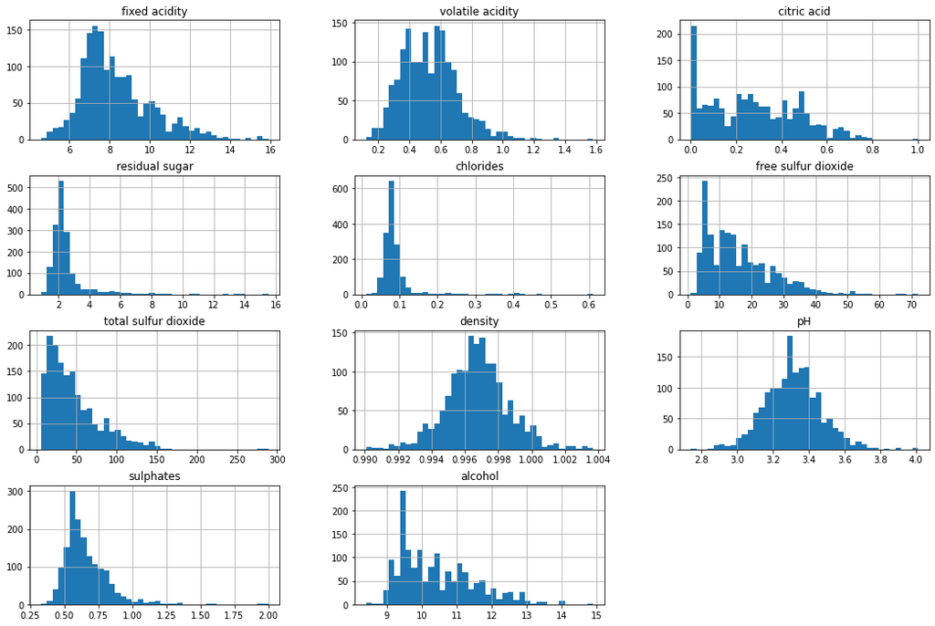

```python
wines_df.drop(["quality", "is_good"], axis=1).hist(bins = 40, figsize=(18, 12))
plt.show()
```

Patrząc na rozkłady zmiennych ciągłych widzimy, że wiele z nich przypomina dosyć mocno rozkład normalny. Spójrzmy jeszcze na rozkład naszych zmiennych kategorycznych dotyczących jakości wina.

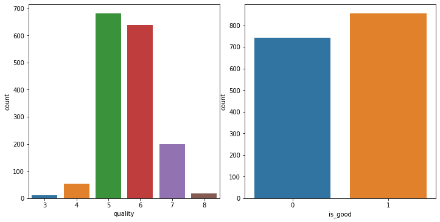

```python
fig, axs = plt.subplots(ncols=2,figsize=(10,5))
fig.tight_layout(pad=1)
sns.countplot(x="quality", data=wines_df, ax=axs[0])
sns.countplot(x="is_good", data=wines_df, ax=axs[1])
```

Teraz zajmiemy się macierzą korelacji.

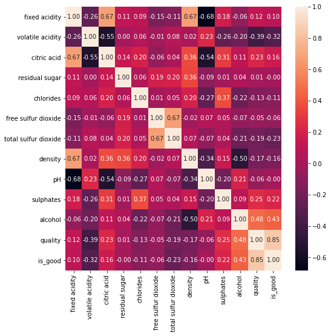

```python
plt.figure(figsize=(8,8))
sns.heatmap(wines_df.corr(), annot=True, annot_kws={'size': 10}, fmt='.2f')
plt.show()
```

Zbadamy teraz zależności pomiędzy najlepiej skorelowanymi ze sobą zmiennymi.

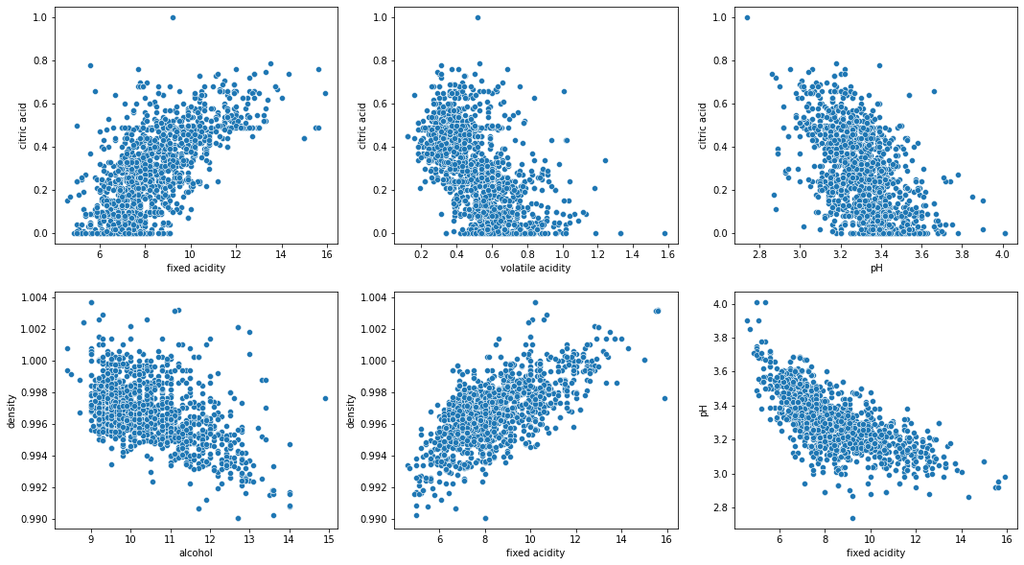

```python
fig, axs = plt.subplots(ncols=3,nrows=2, figsize=(18,10))
sns.scatterplot(data=wines_df, x="fixed acidity", y="citric acid",ax=axs[0, 0])
sns.scatterplot(data=wines_df,x="volatile acidity",y="citric acid",ax=axs[0, 1])
sns.scatterplot(data=wines_df,x="pH",y="citric acid",ax=axs[0, 2])
sns.scatterplot(data=wines_df,x="alcohol",y="density",ax=axs[1, 0])
sns.scatterplot(data=wines_df,x="fixed acidity",y="density",ax=axs[1,1])
sns.scatterplot(data=wines_df,x="fixed acidity",y="pH", ax=axs[1,2])
plt.show()
```

Teraz spójrzmy na to, jak zmienne, które mają największy związek z jakością wina, wpływają na jego ocenę.

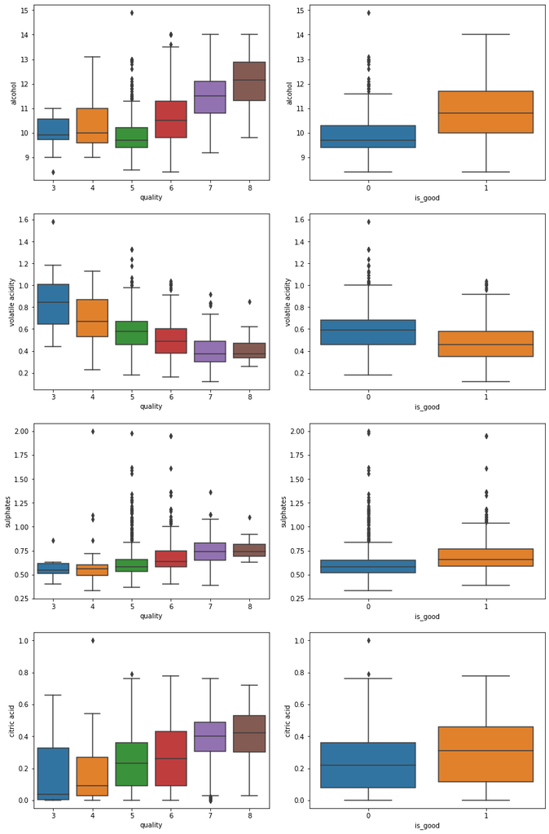

```python
fig, axs = plt.subplots(ncols=2, nrows=4, figsize=(12, 18))
fig.tight_layout(pad=3.0)
sns.boxplot(data=wines_df,x="quality",y="alcohol",ax=axs[0, 0])
sns.boxplot(data=wines_df,x="is_good",y="alcohol",ax=axs[0, 1])
sns.boxplot(data=wines_df,x="quality",y="volatile acidity",ax=axs[1,0])
sns.boxplot(data=wines_df,x="is_good",y="volatile acidity",ax=axs[1,1])
sns.boxplot(data=wines_df,x="quality",y="sulphates",ax=axs[2,0])
sns.boxplot(data=wines_df,x="is_good",y="sulphates",ax=axs[2,1])
sns.boxplot(data=wines_df,x="quality",y="citric acid",ax=axs[3,0])
sns.boxplot(data=wines_df,x="is_good",y="citric acid",ax=axs[3,1])
plt.show()
```

Na koniec weźmiemy dwie zmienne, które mają największy wpływ na jakoś naszego wina - *volatile acidity* i *alcohol*, i sprawdzimy, czy samej ich podstawie dałoby się stwierdzić czy wino jest dobre, czy złe.

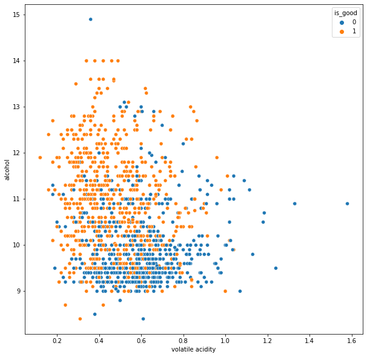

```python
fig, ax = plt.subplots(figsize=(10,10))
sns.scatterplot(data=wines_df,x="volatile acidity",y="alcohol",hue="is_good")
plt.show()
```

Jak widzimy, na takim wykresie da się zaznaczyć obszary, w których występują prawie tylko wina złe bądź dobre, jednak wartość *is_good* dla wielu win ciężko byłoby stwierdzić na podstawie tylko takich informacji.

Przeprowadźmy jeszcze klasyfikację binarną na targecie dobre / złe wino.

W tym celu implementujemy **XGBoost** z tuningiem wybranych hyperparametrów metodą *RandomSearch*.

Najpierw zobaczmy wynik prostej klasyfikacji binarnej extreme gradient boosting, bez poszukiwań dobrych parametrów.

```python
from sklearn.model_selection import train_test_split
import xgboost as xgb
from sklearn.metrics import confusion_matrix
from sklearn.model_selection import RandomizedSearchCV
```

```python
X = wines_df.drop(["quality", "is_good"], axis = 1)
y = wines_df[["is_good"]]
```

```python
test_size = 0.25
X_train, X_test, y_train, y_test = train_test_split(X, y, test_size = test_size, random_state = 1613)
print(X_train.shape)
```

```
(1199, 11)
```

```python
xgb_model = xgb.XGBClassifier(objective = "binary:logistic", seed = 1613, use_label_encoder=False)
xgb_model.fit(X_train, y_train["is_good"])
preds = xgb_model.predict(X_test)

comparison = pd.DataFrame({'actual':y_test['is_good'], 'predicted':preds})
comparison
```

```
[14:54:45] WARNING: C:/Users/Administrator/workspace/xgboost-win64_release_1.3.0/src/learner.cc:1061: Starting in XGBoost 1.3.0, the default evaluation metric used with the objective 'binary:logistic' was changed from 'error' to 'logloss'. Explicitly set eval_metric if you'd like to restore the old …
```

|  | actual | predicted |
| --- | --- | --- |
| 1204 | 1 | 1 |
| 618 | 0 | 1 |
| 845 | 0 | 0 |
| 1154 | 1 | 1 |
| 1174 | 1 | 1 |
| ... | ... | ... |
| 496 | 1 | 1 |
| 260 | 0 | 0 |
| 1498 | 1 | 0 |
| 62 | 1 | 1 |
| 1431 | 1 | 0 |

400 rows × 2 columns

```python
print("Accuracy: " + str(sum(comparison["actual"] == comparison["predicted"]) / len(comparison) * 100) + "%")
```

```
Accuracy: 81.0%
```

```python
tn, fp, fn, tp = confusion_matrix(comparison["actual"], comparison["predicted"]).ravel()
comparison_matrix = pd.DataFrame({"Actual positives": [tp, fp],
                                 "Actual negatives": [tn, fn]},
                                 index = ["Positive predictions", "Negative predictions"])
comparison_matrix
```

|  | Actual positives | Actual negatives |
| --- | --- | --- |
| Positive predictions | 175 | 149 |
| Negative predictions | 35 | 41 |

```python
precision = tp / (tp + fp)
recall = tp / (tp + fn)
f1_score = 2*(precision*recall)/(precision+recall)

print("Precision: " + str(round(precision * 100, 2)) + "%")
print("Recall: " + str(round(recall * 100, 2)) + "%")
print("F1 score: " + str(round(f1_score * 100, 2)) + "%")
```

```
Precision: 83.33%
Recall: 81.02%
F1 score: 82.16%
```

Zobaczmy rezultat z tuningiem hyperparametrów.

```python
import warnings
warnings.filterwarnings('ignore') # kwestia nieistotnego komunikatu

gbm_param_grid = {
    "learning_rate": [0.05, 0.10, 0.15, 0.20, 0.25, 0.30] ,
    "max_depth": [ 3, 4, 5, 6, 8, 10, 12, 15],
    "min_child_weight": [ 1, 3, 5, 7],
    "gamma": [ 0.0, 0.1, 0.2 , 0.3, 0.4],
    "colsample_bytree": [ 0.3, 0.4, 0.5 , 0.7]
}

gbm = xgb.XGBClassifier(objective = "binary:logistic", eval_metric = "logloss", use_label_encoder = False, seed = 1613)

randomized_mse = RandomizedSearchCV(param_distributions = gbm_param_grid,
    estimator = gbm,
    cv = 4,
    n_iter = 1000,
    verbose = 1)

randomized_mse.fit(X_train, y_train)

print("Best parameters found: ", randomized_mse.best_params_)
```

```
Fitting 4 folds for each of 1000 candidates, totalling 4000 fits
Best parameters found:  {'min_child_weight': 1, 'max_depth': 15, 'learning_rate': 0.05, 'gamma': 0.1, 'colsample_bytree': 0.4}
```

```python
preds = randomized_mse.predict(X_test)
preds[0:10]
```

```
array([1, 1, 0, 1, 1, 0, 1, 0, 0, 1])
```

```python
comparison = pd.DataFrame({'actual':y_test['is_good'], 'predicted':preds})
comparison
```

|  | actual | predicted |
| --- | --- | --- |
| 1204 | 1 | 1 |
| 618 | 0 | 1 |
| 845 | 0 | 0 |
| 1154 | 1 | 1 |
| 1174 | 1 | 1 |
| ... | ... | ... |
| 496 | 1 | 1 |
| 260 | 0 | 0 |
| 1498 | 1 | 0 |
| 62 | 1 | 1 |
| 1431 | 1 | 0 |

400 rows × 2 columns

```python
print("Accuracy: " + str(sum(comparison["actual"] == comparison["predicted"]) / len(comparison) * 100) + "%")
```

```
Accuracy: 82.75%
```

```python
tn, fp, fn, tp = confusion_matrix(comparison["actual"], comparison["predicted"]).ravel()
comparison_matrix = pd.DataFrame({"Actual positives": [tp, fp],
                                 "Actual negatives": [tn, fn]},
                                 index = ["Positive predictions", "Negative predictions"])
comparison_matrix
```

|  | Actual positives | Actual negatives |
| --- | --- | --- |
| Positive predictions | 181 | 150 |
| Negative predictions | 34 | 35 |

```python
precision = tp / (tp + fp)
recall = tp / (tp + fn)
f1_score = 2 * precision * recall / (precision + recall)

print("Precision: " + str(round(precision * 100, 2)) + "%")
print("Recall: " + str(round(recall * 100, 2)) + "%")
print("F1 score: " + str(round(f1_score * 100, 2)) + "%")
```

```
Precision: 84.19%
Recall: 83.8%
F1 score: 83.99%
```